# Homework 1 for Stat 340; Introduction to Discrete Random Variables

Karl Rohe

1/22/2020

### 1) Use R to generate a single Bernoulli, Binomial, Geometric, and Poisson random variable.

You can choose the parameter of the distribution to be anything you like.

Here are the function names: `rbernoulli, rbinom, rgeom, rpois`. Think of the “r” as “generate **R**andom number”.

### 1a) What are the 8 headings in each of the help files?

Reading the help files is hard at first, but it is an essential skill. Have a look at their help files. What are the 8 headings?

```r
?rbinom
?rgeom
?rpois
```

### 1b) Generate a single copy of each random variable.

```r
# generate a single Bernoulli random variable:
library(purrr)
rbernoulli(n = 1, p=.5)
```

```
## [1] FALSE
```

```r
# generate a single Binomial random variable:
rbinom(n = 1, size = 10, prob = .3)
```

```
## [1] 3
```

```r
# generate a single Geometric random variable:

# generate a single Poisson random variable:
```

### 1c) Generate ten copies of each random variable.

```r
# generate 10 Bernoulli random variables:
rbernoulli(n = 10, p=.5)
```

```
##  [1] FALSE FALSE FALSE FALSE  TRUE  TRUE  TRUE FALSE  TRUE FALSE
```

```r
# generate 10 Binomial random variables:

# generate 10 Geometric random variables:

# generate 10 Poisson random variables:
```

### 2) Make a histogram

One way to think about random variables is through their “distribution”. To see what the distribution of a random variable looks like, generate 10,000 copies of the random variables above and put them in a histogram:

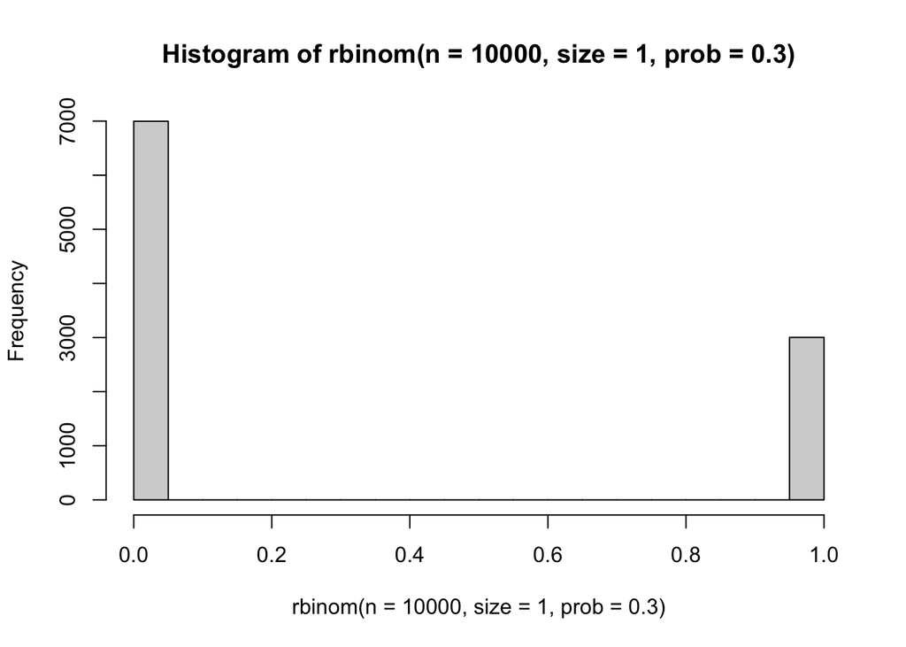

```r
# Bernoulli:
hist(rbinom(n = 10000,size = 1,prob = .3))
```

```r
# or
library(magrittr)
```

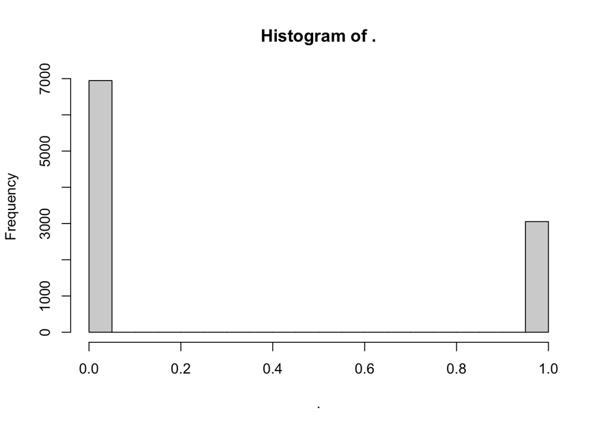

```r
rbinom(10000,1,.3) %>% hist
```

```r
# Binomial:

# Geometric:

# Poisson:
```

Repeat the last step, but change the value of the parameter that you put in.

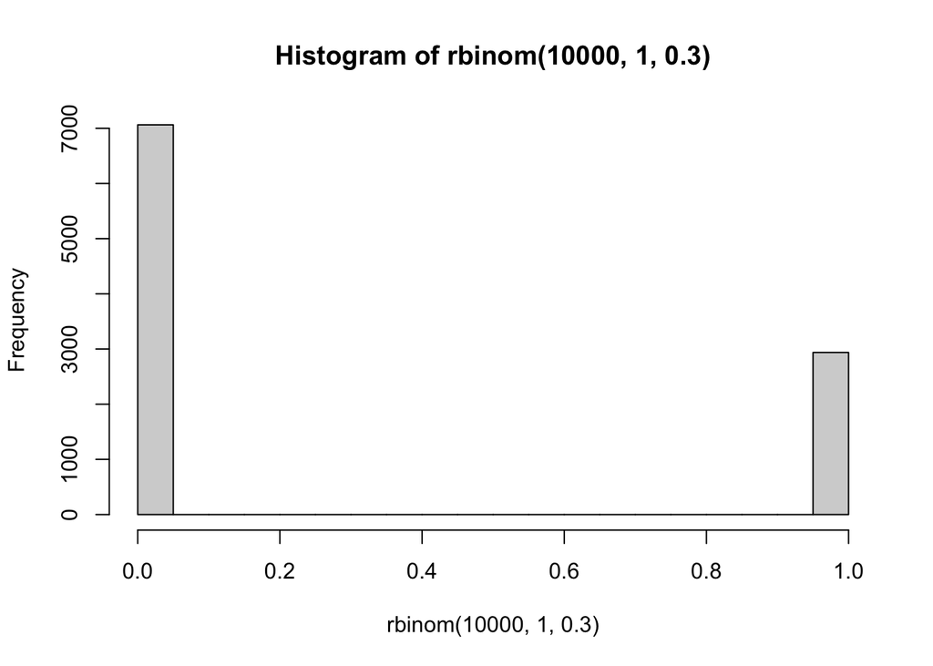

```r
# Bernoulli:
hist(rbinom(10000,1,.3))
```

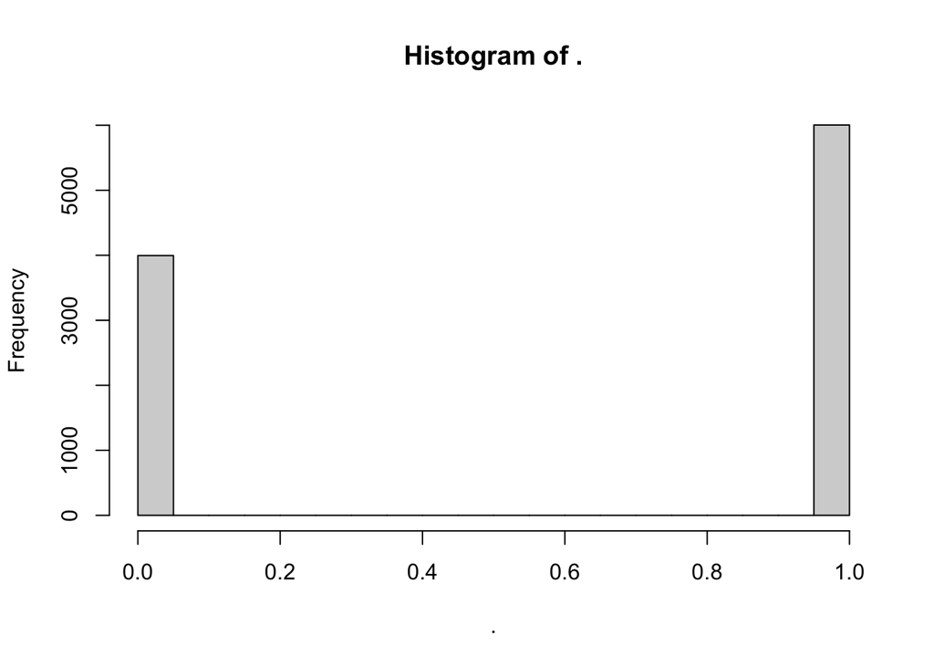

```r
# or
library(magrittr)
rbinom(10000,1,.6) %>% hist
```

```r
# Binomial:

# Geometric:

# Poisson:
```

### 3) What happens to the histogram when the parameter gets bigger?

Answer in words:

1. Bernoulli: The Bernoulli histogram “moves to the right” when the parameter p gets bigger.
2. Binomial:
3. Geometric:
4. Poisson:

### 4) For next week:

Before next week’s homework, write down a sequence of heads and tails of length 200 in the code chunk below. *Make the sequence as random as possible without actually flipping a coin or generating randomv variables on the computer.* Just **try** to make them random by writing them down.

```r
# Turn on caps lock and let it rip:
myFlips = "HTHHTHTHTTHH..."
nchar(myFlips)  #make sure it length 200
```

```
## [1] 15
```